# DDS Case Study

# Question 9 - Other Insights - ABV by Ounces

```r
library(usmap)
```

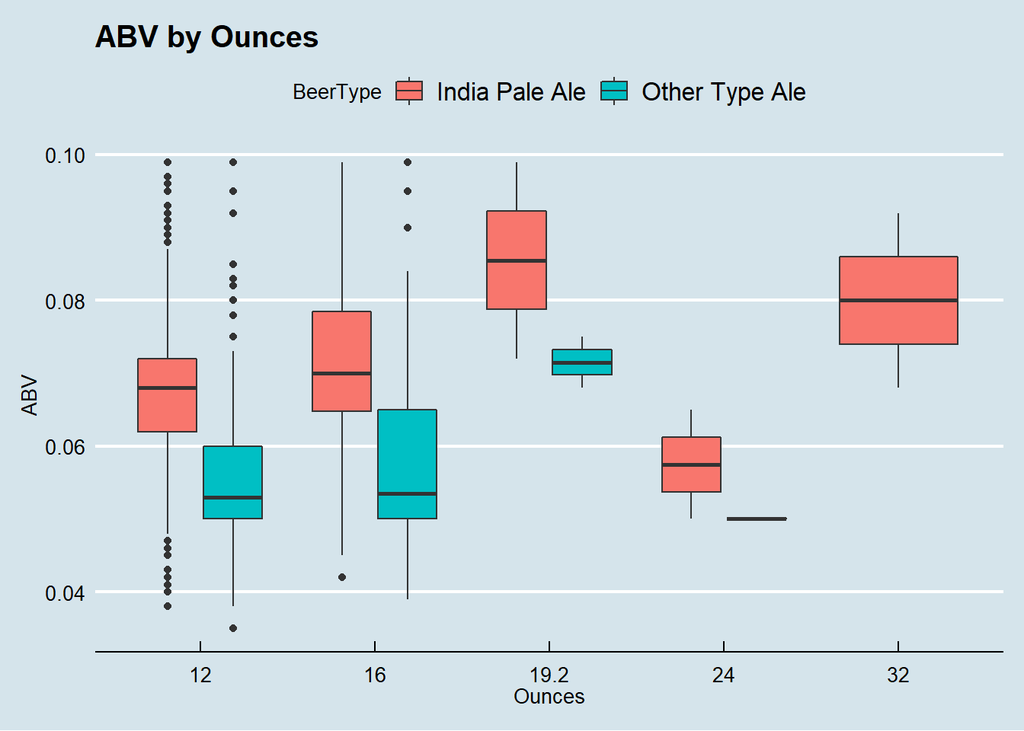

```r
library(ggplot2)
library(mapproj)
BrewPubIPAOther$Ounces<-as.factor(BrewPubIPAOther$Ounces)

BrewPubIPAOther %>% ggplot(mapping=aes(x=Ounces, y=ABV, fill=BeerType)) + geom_boxplot() +
  ggtitle("ABV by Ounces") + theme_economist()
```

#We can see that it the median ABV value appears to increase as ounces increase, with the execption of 24 and 32 ounces. However, more in-depth statistical testing would need to be done in order to determine if there was a significant relationship.

# Question 9 - Other Insights - Median ABV by State (continued)

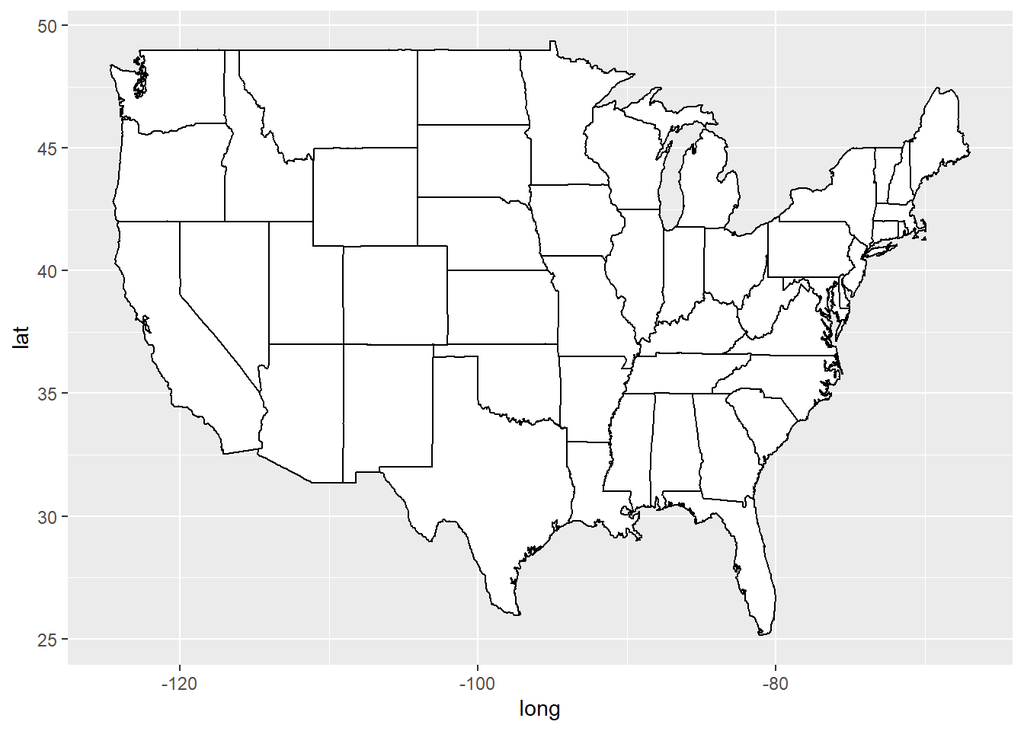

```r
#In order to more clearly visualize the median ABV value for each state, we believed a heat map of the United States would be more efficient.

#Get Map Data
states <- map_data("state")

#Test plot of US
states %>% ggplot(mapping=aes(x=long, y=lat, group=group, fill=region)) +
  geom_polygon(fill="white", color="black")
```

```r
beerbybrew1 = BrewPub %>% filter(!is.na(ABV))

###Median of ABV by state###
abvmed = summaryBy(ABV~State, data=beerbybrew1, FUN=median)

#Get State names instead of abbreviations
abvmed1=abvmed
abvmed1$State<-as.character(abvmed1$State)

#Get rid of white space on left of abbreviation
abvmed1=abvmed1%>%mutate(State=str_trim(State))

#Do mutation on ABV percentage and getting state full name
abvmed2=abvmed1%>%mutate(State=abbr2state(State), ABV.median=ABV.median*100)
head(abvmed2)
```

```
##        State ABV.median
## 1     Alaska       5.60
## 2    Alabama       6.00
## 3   Arkansas       5.20
## 4    Arizona       5.50
## 5 California       5.80
## 6   Colorado       6.05
```

```r
#changing state to lowercase
abvmed3=abvmed2%>%mutate(State=tolower(State))
head(abvmed3)
```

```
##        State ABV.median
## 1     alaska       5.60
## 2    alabama       6.00
## 3   arkansas       5.20
## 4    arizona       5.50
## 5 california       5.80
## 6   colorado       6.05
```

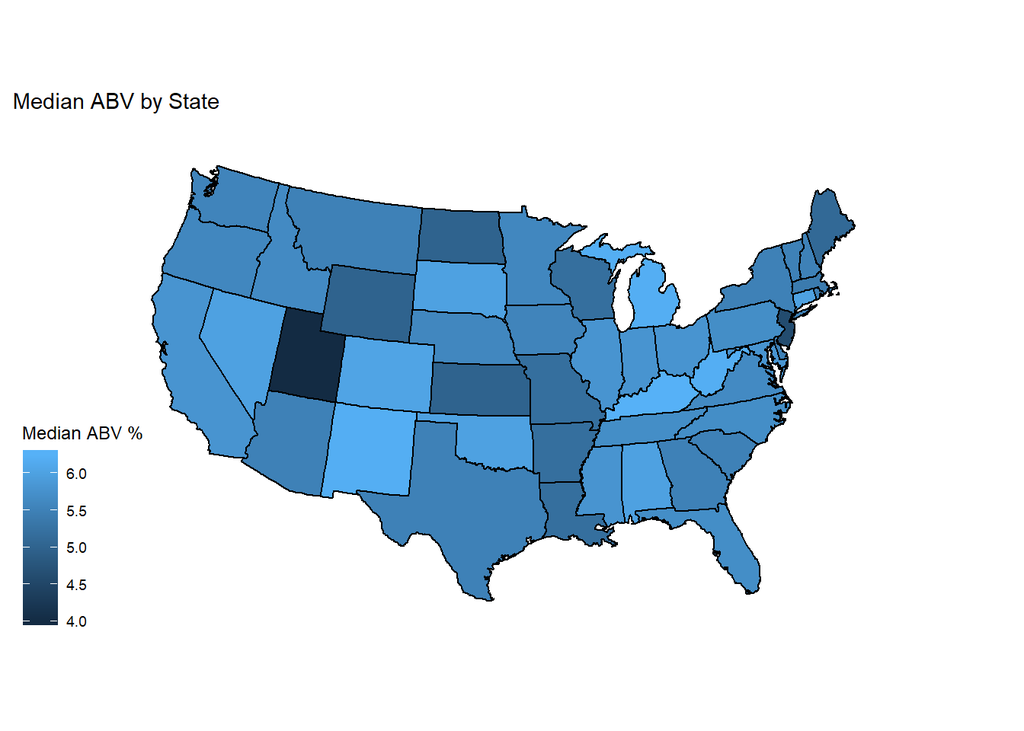

```r
#left_join to get long and lat for each stae
beerloc=left_join(states,abvmed3, by=c("region"="State"))

#Change ABV.Median to factor
beerloc$ABV.median<-as.numeric(beerloc$ABV.median)

#Plot ABV median by state
beerloc %>% ggplot(mapping=aes(x=long, y=lat, group=group, fill=ABV.median)) +
  geom_polygon(color="black") +
  coord_map(projection="albers", lat0=39, lat1=45) +
  labs(title="Median ABV by State") +
  theme_map() +
  labs(fill="Median ABV %")
```

#The map clearly shows thte states with higher ABV values. ONe state that sticks out is Utah–it is significantly darker than the rest of the states.